# Data Storytelling Project: What Factors Influence California Housing Prices?

Ching Yi Lam

2026-05-31

# 1 Introduction and Motivation

## 1.1 Background Story and Data Generation Process

The California Housing dataset was collected from the 1990 United States Census and contains information about housing blocks throughout California.A block group on average includes 1425.5 individuals living a geographically compact area. The dataset includes demographic, geographic, and housing-related characteristics such as population, household income, number of rooms, and proximity to the ocean.

The primary goal of this dataset is to understand the factors that influence housing values across different regions of California. Housing prices are affected by many variables, including location, income levels, and housing characteristics. By exploring these relationships through data visualization, we can identify important trends and patterns that help explain differences in housing values.

**Data Dictionary**

Population: The dataset contains 20,640 observations and 10 variables.

```r
# Create an interactive data dictionary
data_dictionary <- tribble(
  ~Variable_Name,    ~Description,                                                        ~Variable_Type,
  "Longitude",          "Geographic longitude",       "Continuous",
  "Latitude",          "Geographic latitude",  "Continuous",
  "housingMedianAge",          "Median house age",              "Continuous",
  "totalRooms",          "Total rooms in block",  "Discrete",
  "totalBedrooms",          "Total bedrooms in block",  "Discrete",
  "population",          "Population in block",  "Discrete",
  "households",          "Number of households",  "Discrete",
  "medianIncome",          "Median income",  "Continuous",
  "medianHouseValue",          "Median house value",  "Continuous",
  "oceanProximity",          "Location relative to ocean",  "Categorical"
  # Add more rows as needed
)

datatable(
  data_dictionary,
  caption = "Table 1: Variable definitions and types for the analysis dataset",
  rownames = FALSE,
  options = list(pageLength = 10, dom = 'tip')
)
```

| Variable_Name | Description | Variable_Type |
| --- | --- | --- |
| Longitude | Geographic longitude | Continuous |
| Latitude | Geographic latitude | Continuous |
| housingMedianAge | Median house age | Continuous |
| totalRooms | Total rooms in block | Discrete |
| totalBedrooms | Total bedrooms in block | Discrete |
| population | Population in block | Discrete |
| households | Number of households | Discrete |
| medianIncome | Median income | Continuous |
| medianHouseValue | Median house value | Continuous |
| oceanProximity | Location relative to ocean | Categorical |

## 1.2 Business Questions and Hypotheses

The purpose of collecting this dataset was to understand the factors that influence housing values across different regions of California and to identify the characteristics assoicated with higher-priced housing markets.

**Question 1**: What is the relationship between household income and median house value in California?

**Question 2**: Does proximity to the ocean influence median house values?

**Question 3**: How do geographic location characteristics (latitude and longitude) affect housing prices across California?

Hypotheses derived from domain knowledge:

**H1**: Census block groups with higher median household incomes tend to have higher median house values.

**H2**: Houses located closer to the ocean have higher median values than houses located inland.

**H3**: Housing values vary significantly across different geographic regions of California, with coastal areas generally exhibiting higher prices than inland areas.

These hypotheses will guide our exploratory visual analysis and help us identify the key factors associated with housing values in California.

# 2 Visual Exploratory Analytic Plan

**Narrative of the plan**: Before drawing conclusions about California housing prices, it is important to understand the structure, quality, and underlying patterns within the dataset. This visual exploratory data analysis (V-EDA) aims to examine the distribution of housing, demographic, and geographic variables and identify the factors associated with median house values.

The analysis will be conducted in three phases. First, we will assess data quality by examining missing values, variable types, and potential data issues. Second, we will perform univariate analyses to understand the distribution and characteristics of individual variables such as median income, housing age, and median house value. Finally, we will conduct bivariate and multivariate analyses to explore relationships between variables, focusing on how income, location, and proximity to the ocean influence housing prices.

These analyses will help address the research questions and evaluate the proposed hypotheses regarding the determinants of housing values in California.

## 2.1 Overall Data Inspection — Missing Values and Data Quality

**Goal**:

- Assess the completeness and overall condition of the California Housing dataset before beginning the analysis.
- Visualize the missing data pattern using an aggregated heatmap or upset plot.
- Check for possible data issues, such as zero or negative values in population, households, total rooms, total bedrooms, median income, or median house value.
- Confirm that numerical variables and the categorical variable, oceanProximity, are correctly formatted before creating visualizations.

## 2.2 Variable Inspections — Distribution Analysis

**Goal**: Understand the central tendency, variability, and distribution of each variable individually.

- **Numeric variables**: Use histograms with density curves and boxplots to examine the distributions of longitude, latitude, housingMedianAge, medianIncome, and medianHouseValue. Use histograms and boxplots to explore the distributions of totalRooms, totalBedrooms, population, and households.
- **Categorical variables**: Use bar charts to visualize the frequency distribution of oceanProximity categories and identify the most common housing locations relative to the ocean.

## 2.3 Relationships Between Variables

**Goal**: Investigate the associations and interactions that underpin our business questions.

- **Numerical vs. Numerical**: Use scatterplots with regression or LOESS trend lines to examine relationships between medianHouseValue and key numerical variables such as medianIncome, housingMedianAge, population, and households. A correlation matrix will be used to summarize the strength and direction of relationships among numerical variables.
- **Categorical vs. Categorical**: If needed, use grouped or stacked bar charts to examine associations between oceanProximity categories and other derived categorical groupings created during the analysis.
- **Numerical vs. Categorical**: Use boxplots and violin plots to compare the distributions of medianHouseValue across different oceanProximity categories. These visualizations will help determine whether housing values differ significantly based on proximity to the ocean.

# 3 Effective Visual Design

## 3.1 Section: Data Quality and Missing Value Assessment

### 3.1.1 Missing Data Pattern

**Opening paragraph**: Before exploring relationships among housing prices, income, and geographic characteristics, it is important to assess the completeness and quality of the dataset. Missing values can reduce the accuracy of statistical summaries and visualizations if not properly addressed. This visualization examines the proportion of missing values across all variables in the California Housing dataset, helping us identify potential data quality concerns and determine whether any data cleaning or imputation procedures are necessary before conducting further analysis.

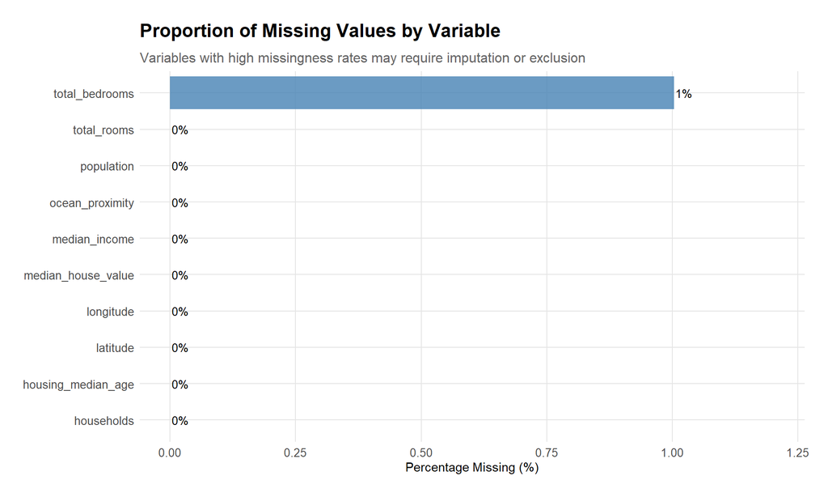

```r
df <- read.csv("housing.csv")
# Proportion missing by variable
missing_summary <- df %>%
  summarise(across(everything(), ~ mean(is.na(.)) * 100)) %>%
  pivot_longer(everything(), names_to = "variable", values_to = "pct_missing") %>%
  arrange(desc(pct_missing))

ggplot(missing_summary, aes(x = reorder(variable, pct_missing), y = pct_missing)) +
  geom_col(fill = "steelblue", alpha = 0.8) +
  geom_text(aes(label = paste0(round(pct_missing, 1), "%")), hjust = -0.1, size = 3.5) +
  coord_flip() +
  scale_y_continuous(limits = c(0, max(missing_summary$pct_missing) * 1.2)) +
  labs(
    title = "Proportion of Missing Values by Variable",
    subtitle = "Variables with high missingness rates may require imputation or exclusion",
    x = NULL,
    y = "Percentage Missing (%)"
  ) +
  theme_storytelling
```

**Summary of Observations and Implications**: The missing value assessment indicates that the California Housing dataset is highly complete. Only the total_bedrooms variable contains missing values, accounting for approximately 1% of the observations. All other variables have no missing data.

The low level of missingness suggests that data quality is generally excellent and is unlikely to significantly affect the results of the analysis. Since the missing values are concentrated in a single variable and represent a very small proportion of the dataset, several approaches can be considered, including median imputation or removing the incomplete observations.

Given that over 99% of the data is complete, the missing values in total_bedrooms are not expected to introduce substantial bias. Therefore, the dataset is suitable for exploratory data analysis and visualization without major concerns regarding data completeness.

## 3.2 Univariate Distribution Analysis

### 3.2.1 Distributions of Key Numeric Variables

**Opening paragraph**: Understanding the distribution of individual variables is a critical step in exploratory data analysis. Examining the shape, center, spread, and potential outliers of each variable helps identify important characteristics that may influence subsequent analyses. In this section, histograms with density curves are used to visualize the distributions of the numerical variables in the California Housing dataset, while vertical reference lines representing the mean and median help highlight skewness and asymmetry. These visualizations provide valuable insights into the housing, demographic, and geographic characteristics of California census block groups and help guide further investigation of factors associated with housing values.

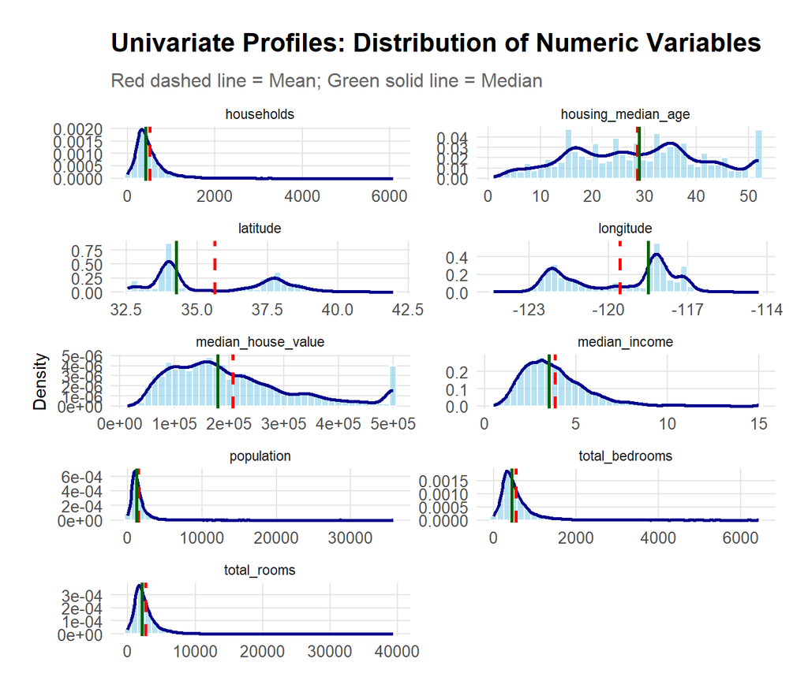

```r
# Reshape numeric variables to long format for faceted plotting
df_numeric_long <- df %>%
  select(where(is.numeric)) %>%
  pivot_longer(everything(), names_to = "variable", values_to = "value")

ggplot(df_numeric_long, aes(x = value)) +
  geom_histogram(aes(y = after_stat(density)), bins = 40, fill = "skyblue", alpha = 0.6, color = "white") +
  geom_density(color = "darkblue", linewidth = 1) +
  geom_vline(data = . %>%
               group_by(variable) %>%
               summarise(mean = mean(value, na.rm = TRUE), median = median(value, na.rm = TRUE)),
             aes(xintercept = mean), linetype = "dashed", color = "red", linewidth = 1) +
  geom_vline(data = . %>%
               group_by(variable) %>%
               summarise(mean = mean(value, na.rm = TRUE), median = median(value, na.rm = TRUE)),
             aes(xintercept = median), linetype = "solid", color = "darkgreen", linewidth = 1) +
  facet_wrap(~ variable, scales = "free", ncol = 2) +
  labs(
    title = "Univariate Profiles: Distribution of Numeric Variables",
    subtitle = "Red dashed line = Mean; Green solid line = Median",
    x = NULL, y = "Density"
  ) +
  theme_storytelling
```

**Summary of Observations and Implications**: The univariate distribution analysis reveals several important characteristics of the California Housing dataset. Variables such as total_rooms, total_bedrooms, population, and households exhibit strong right-skewness, indicating that most census block groups are relatively small while a few contain exceptionally large numbers of rooms, bedrooms, households, or residents. Similarly, median_income is moderately right-skewed, suggesting that high-income neighborhoods are less common than middle-income neighborhoods.

In contrast, geographic variables such as latitude and longitude display multiple peaks, reflecting the concentration of population centers in different regions of California. The distribution of housing_median_age appears relatively broad, indicating substantial variation in the age of housing across census block groups. The distribution of median_house_value is right-skewed and shows evidence of a ceiling effect near $500,000, which reflects the maximum value recorded in the dataset.

These distributional patterns have important implications for subsequent analyses. The strong skewness observed in several variables suggests that transformations or robust statistical methods may be useful when examining relationships among variables. The apparent clustering in geographic variables indicates that location is likely an important factor influencing housing prices. Furthermore, the variation observed in median_income and median_house_value supports the investigation of income and geographic characteristics as potential determinants of housing values in California.

### 3.2.2 Distributions of Categorical Variables

**Opening paragraph**: Categorical variables help identify meaningful groups within a dataset and allow researchers to compare outcomes across different categories. In the California Housing dataset, the ocean_proximity variable classifies census block groups according to their location relative to the ocean. Examining the frequency distribution of these categories provides insight into the geographic composition of the dataset and helps identify any class imbalances that may influence subsequent analyses. Understanding the distribution of ocean proximity categories is particularly important because location is expected to play a significant role in determining housing values throughout California.

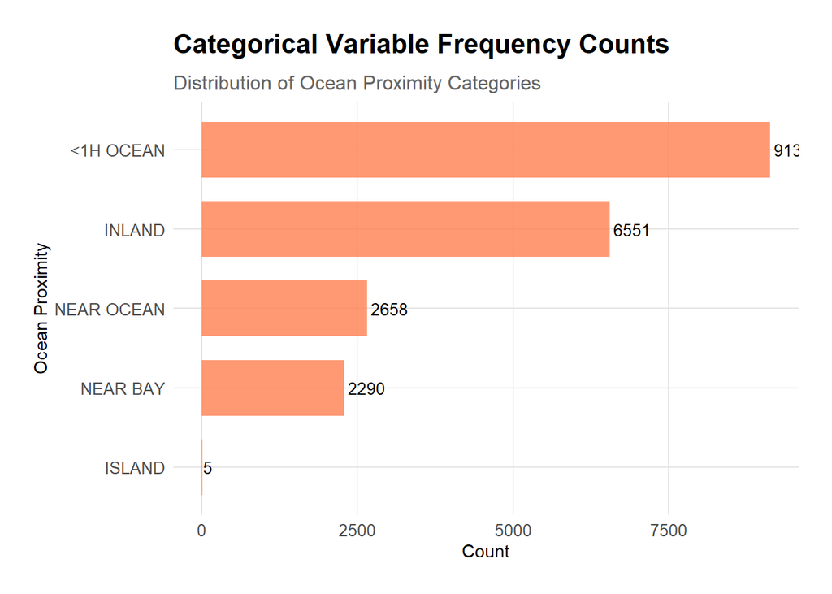

```r
# Use the actual categorical variable from the California Housing dataset
df_categorical <- df %>%
  select(ocean_proximity) %>%
  mutate(ocean_proximity = factor(ocean_proximity))

# Frequency count for ocean_proximity
category_counts <- df_categorical %>%
  count(ocean_proximity) %>%
  arrange(desc(n))

ggplot(category_counts,
       aes(x = reorder(ocean_proximity, n), y = n)) +
  geom_col(fill = "coral", alpha = 0.8, width = 0.7) +
  geom_text(aes(label = n), hjust = -0.1, size = 3.5) +
  coord_flip() +
  labs(
    title = "Categorical Variable Frequency Counts",
    subtitle = "Distribution of Ocean Proximity Categories",
    x = "Ocean Proximity",
    y = "Count"
  ) +
  theme_storytelling
```

**Summary of Observations and Implications**: The frequency distribution of the ocean_proximity variable reveals substantial differences in the number of observations across categories. The largest category is <1H OCEAN with 9,130 observations, followed by INLAND with 6,551 observations. The NEAR OCEAN and NEAR BAY categories contain 2,658 and 2,290 observations, respectively. In contrast, the ISLAND category contains only 5 observations, making it extremely underrepresented in the dataset.

These results suggest that most California census block groups in the dataset are located either inland or within one hour of the ocean. The severe imbalance in the ISLAND category may limit the reliability of statistical comparisons involving this group. For subsequent analyses, it may be appropriate to combine the ISLAND category with another coastal category or exclude it from certain visualizations and statistical models due to its very small sample size.

The observed differences in ocean proximity categories support further investigation into whether location relative to the ocean influences housing prices. Since proximity to the coast is often associated with higher property values, ocean_proximity is expected to be an important explanatory variable in understanding variation in California housing prices.

## 3.3 Relationships Between Variables

### 3.3.1 Correlation and Trend Discovery

**Opening paragraph**: Understanding the relationships among numerical variables is essential for identifying the factors that influence housing values in California. A scatterplot matrix combined with Pearson correlation coefficients and LOESS trend lines allows us to examine the strength, direction, and potential non-linear nature of associations among key housing, demographic, and geographic variables. This analysis helps identify important predictors of median house value, detect potential multicollinearity among explanatory variables, and uncover patterns that may not be apparent from summary statistics alone.

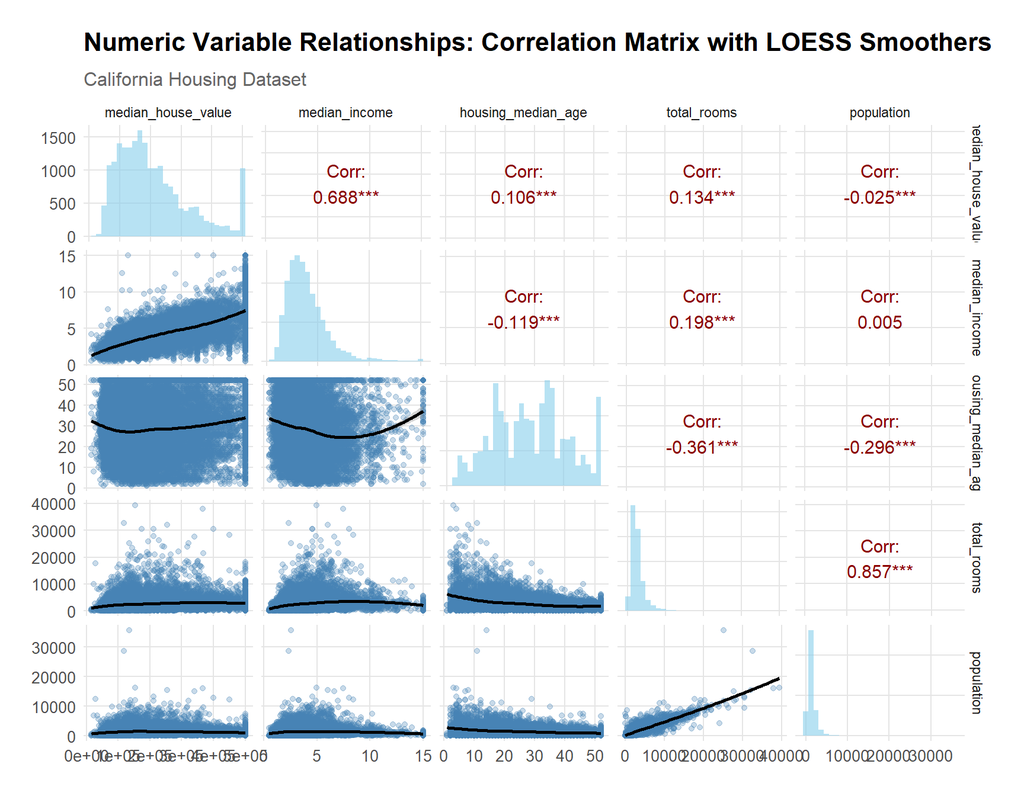

```r
# Select key numeric variables from the California Housing dataset
df4 <- df %>%
  select(
    median_house_value,
    median_income,
    housing_median_age,
    total_rooms,
    population,
    households
  ) %>%
  select(1:5) %>%
  drop_na()

# Create scatterplot matrix with correlations
ggpairs(
  df4,
  lower = list(
    continuous = wrap(
      "smooth",
      method = "loess",
      se = TRUE,
      alpha = 0.3,
      color = "steelblue"
    )
  ),
  diag = list(
    continuous = wrap(
      "barDiag",
      fill = "skyblue",
      alpha = 0.6
    )
  ),
  upper = list(
    continuous = wrap(
      "cor",
      size = 4,
      color = "darkred"
    )
  )
) +
  labs(
    title = "Numeric Variable Relationships: Correlation Matrix with LOESS Smoothers",
    subtitle = "California Housing Dataset"
  ) +
  theme_storytelling
```

**Summary of Observations and Implications**: The correlation matrix reveals several important relationships among the numerical variables in the California Housing dataset. The strongest positive relationship is observed between median_income and median_house_value (r = 0.688), indicating that higher-income neighborhoods tend to have higher housing values. This finding provides strong preliminary support for Hypothesis 1 and suggests that income is a key factor influencing housing prices.

Another notable relationship exists between total_rooms and population (r = 0.857), reflecting that census block groups with larger populations generally contain more housing units and rooms. In contrast, housing_median_age exhibits moderate negative correlations with both total_rooms (r = -0.361) and population (r = -0.296), suggesting that older neighborhoods tend to have fewer rooms and smaller populations.

Most of the remaining correlations are relatively weak, indicating limited linear associations among those variables. The LOESS smoothers further suggest that some relationships may be non-linear, particularly for housing age and housing value. Overall, the analysis highlights median_income as the strongest predictor of housing value and supports further investigation of income and location-related factors in explaining variation in California housing prices.

### 3.3.2 Comparing Distributions Across Groups

**Opening paragraph**: To investigate whether housing values differ across geographic location categories, we compare the distribution of median house values for each ocean proximity group. Rather than focusing solely on average house values, violin plots display the full distribution of housing prices, including the center, spread, density, and potential multimodality within each category. This approach provides a more comprehensive understanding of how housing markets vary according to proximity to the ocean and helps evaluate whether location is associated with differences in housing values.

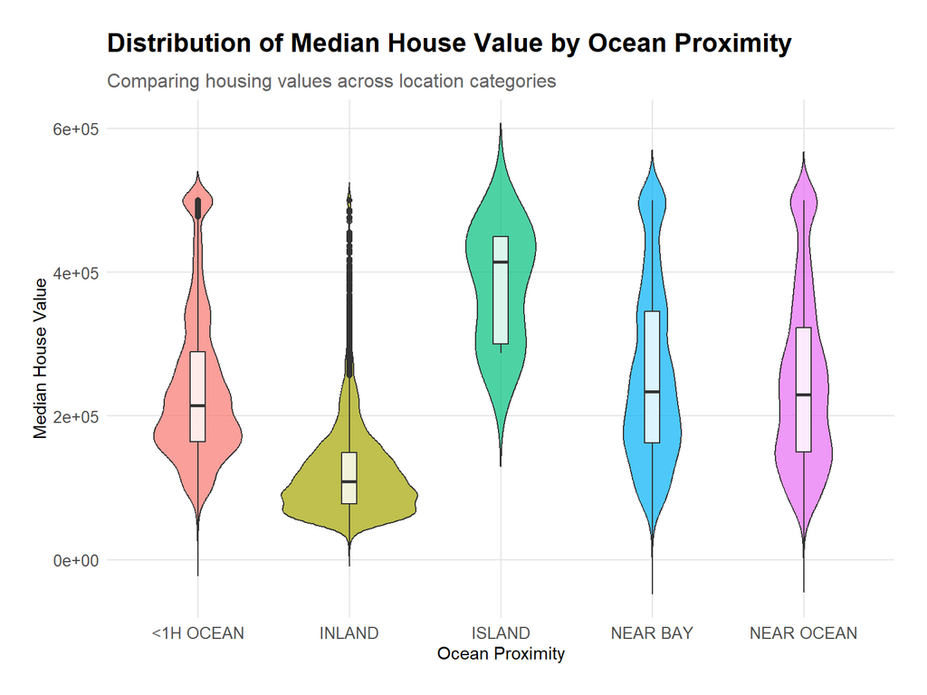

```r
ggplot(df, aes(x = ocean_proximity,
               y = median_house_value,
               fill = ocean_proximity)) +
  geom_violin(trim = FALSE, alpha = 0.7) +
  geom_boxplot(width = 0.1, fill = "white", alpha = 0.8) +
  labs(
    title = "Distribution of Median House Value by Ocean Proximity",
    subtitle = "Comparing housing values across location categories",
    x = "Ocean Proximity",
    y = "Median House Value"
  ) +
  theme_storytelling +
  theme(legend.position = "none")
```

**Summary of Observations and Implications**: The violin plot reveals substantial differences in median house values across ocean proximity categories. The INLAND category has the lowest housing values overall, with a relatively concentrated distribution centered at lower price levels. In contrast, <1H OCEAN, NEAR BAY, and NEAR OCEAN exhibit higher median house values and wider distributions, indicating greater variation in housing prices among coastal communities.

The ISLAND category appears to have the highest housing values; however, this category contains only a small number of observations and should therefore be interpreted with caution. Several categories display evidence of multiple peaks in their distributions, suggesting that housing markets within the same ocean proximity category may not be homogeneous and could contain distinct subgroups.

These findings provide preliminary support for the hypothesis that proximity to the ocean is associated with higher housing values. The results suggest that ocean_proximity is an important explanatory variable and should be included in subsequent analyses aimed at understanding the determinants of California housing prices.

### 3.3.3 Contingency and Association

**Opening paragraph**: Understanding the association between categorical variables helps identify whether certain groups are more likely to occur together than would be expected by chance. In this analysis, the original categorical variable ocean_proximity is compared with a newly created categorical variable, income_group, derived from median_income. A normalized stacked bar chart is used to examine how the distribution of income groups varies across different ocean proximity categories. This visualization helps determine whether household income patterns differ by location and provides insight into the potential relationship between geographic location and housing market characteristics.

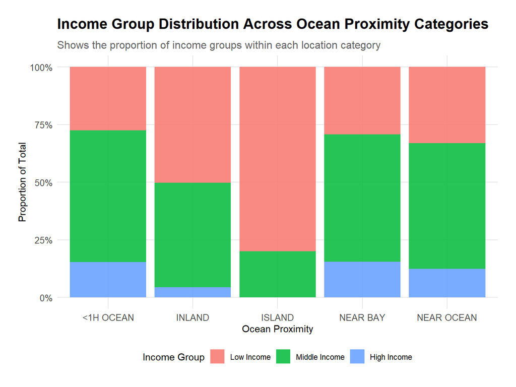

```r
# Create income groups from median_income
df5 <- df %>%
  mutate(
    income_group = case_when(
      median_income < 3 ~ "Low Income",
      median_income >= 3 & median_income < 6 ~ "Middle Income",
      median_income >= 6 ~ "High Income"
    ),
    income_group = factor(
      income_group,
      levels = c("Low Income", "Middle Income", "High Income")
    )
  )

# Stacked proportional bar chart
ggplot(df5, aes(x = ocean_proximity, fill = income_group)) +
  geom_bar(position = "fill", alpha = 0.85) +
  scale_y_continuous(labels = scales::percent) +
  labs(
    title = "Income Group Distribution Across Ocean Proximity Categories",
    subtitle = "Shows the proportion of income groups within each location category",
    x = "Ocean Proximity",
    y = "Proportion of Total",
    fill = "Income Group"
  ) +
  theme_storytelling
```

**Summary of Observations and Implications**: To examine the relationship between location and income, a new categorical variable called income_group was created from the continuous variable median_income. Households were classified into low, middle, and high income groups, allowing a comparison of income distributions across different ocean_proximity categories.

The stacked bar chart reveals that the distribution of income groups varies across ocean proximity categories. Areas located closer to the ocean generally contain a larger proportion of middle- and high-income households, while inland areas tend to have a higher proportion of low-income households. These differences suggest that geographic location and household income are related and may jointly influence housing values.

The observed variation across categories supports the hypothesis that location plays an important role in California housing markets. Since both ocean_proximity and income_group appear to be associated with housing characteristics, these variables should be considered important predictors in subsequent analyses of median house values. Furthermore, the results suggest that the relationship between income and housing prices may differ across geographic regions, warranting further investigation.

# 4 Effective Visual Storytelling: From Insights to Action

**Opening paragraph**: The visual analyses conducted throughout this project provide valuable insights into the factors associated with housing values in California. By examining distributions, correlations, and group differences, we identified important relationships among income, location, and housing prices. This section synthesizes the key findings and discusses how these insights can support decision-making in housing market analysis, urban planning, and real estate investment.

## 4.1 How to Use Visual Insights to Support Business Decisions

The visual evidence gathered in this analysis informs several important housing market and planning decisions:

**Decision on Income and Housing Value**: The correlation analysis revealed a strong positive relationship between median income and median house value. Communities with higher household incomes tend to have substantially higher housing prices. Recommendation: Real estate developers, investors, and policymakers should consider local income levels when evaluating housing demand, property values, and future development opportunities.

**Decision on Location and Housing Value**: The violin plots demonstrated that housing values differ considerably across ocean proximity categories. Properties located near the ocean or bay generally have higher median values than inland properties. Recommendation: Geographic location should be considered a key factor in property valuation, housing investment strategies, and regional planning decisions.

**Decision on Housing Market Segmentation**: The categorical analysis showed that income groups vary across ocean proximity categories, suggesting that different housing markets exist within California. Recommendation: Housing policies and development strategies should be tailored to the characteristics of specific regions rather than applying a single statewide approach. Coastal and inland housing markets may require different planning priorities and affordability strategies.

## 4.2 How to Use Visual Findings to Inform Subsequent Data Analysis and Modeling

The exploratory visual analysis provides a strong foundation for future statistical modeling and housing market research.

**Feature Engineering**: The distribution analysis revealed substantial right-skewness in variables such as total_rooms, total_bedrooms, population, and households. Applying logarithmic transformations or creating density-based measures (e.g., rooms per household or bedrooms per household) may improve model performance and provide more meaningful interpretations of housing characteristics.

**Model Selection**: The correlation analysis identified median_income as the strongest predictor of median_house_value, while the violin plots highlighted important differences across ocean_proximity categories. These findings suggest that multiple linear regression, generalized additive models, or tree-based methods may be useful for predicting housing values while capturing both linear and non-linear relationships.

**Handling Missing Data**: The missing value assessment showed that only total_bedrooms contains missing values, representing approximately 1% of the dataset. Because the level of missingness is low, median imputation or removal of incomplete observations is unlikely to substantially affect the results. The remaining variables contain complete data and require minimal preprocessing.

**Hypothesis Validation**: The visual evidence provides preliminary support for all three hypotheses. Higher-income neighborhoods generally exhibit higher housing values, housing prices vary across ocean proximity categories, and geographic location appears to influence housing markets throughout California. Future analyses may include formal hypothesis tests and predictive modeling techniques to quantify the strength and statistical significance of these relationships.

## 4.3 Dashboard and Interactive Housing Market Monitoring

If this project were expanded into an interactive dashboard, the visualizations could be organized to help users explore housing market characteristics and factors influencing home values across California.

The layout of the dashboard should mirror the storytelling narrative we’ve constructed, organized in three logical tabs:

**Tab 1: “Data Quality Overview”** — Display the missing value assessment and summary statistics for each variable. This tab would allow users to monitor data completeness and identify potential quality issues before conducting further analysis.

**Tab 2: “Housing Market Explorer”** — Feature the distribution plots, correlation matrix, and geographic visualizations. Users could interactively explore relationships between median income, housing characteristics, and median house values, while filtering observations by ocean proximity or geographic region.

**Tab 3: “Location and Price Analysis”** — Display the violin plots and categorical comparisons involving ocean proximity and income groups. This tab would help users compare housing values across different location categories and identify geographic patterns in the California housing market.

The dashboard could be implemented using Shiny or Quarto, allowing users to dynamically explore housing market trends and relationships among variables. Interactive filtering and visualization tools would provide a practical way to investigate how income, location, and housing characteristics contribute to variations in median house values.

This concludes the data storytelling project. The analysis demonstrates that income, geographic location, and proximity to the ocean are important factors associated with housing values in California. Through visual exploration, we identified meaningful patterns that provide insights into the structure of California’s housing market and establish a foundation for future statistical modeling and housing market research.